# Capstone Project

This is a data visualization and manipulation part of our capstone project. The data is from AMC company.

### Loading the data into R notebook

```r
amcdata<-read.csv("C:/Users/jiena_000/Desktop/Capstone Project/AMCSampleData_InsiderPremier.csv", stringsAsFactors = F )
head(amcdata)
```

```
##   ISPREMIER AGE21PLUSINDICATOR AGE18TO21INDICATOR AGE13TO18INDICATOR
## 1         1                  1                  0                  0
## 2         1                  1                  0                  0
## 3         1                  1                  0                  0
## 4         0                  1                  0                  0
## 5         1                  1                  0                  0
## 6         1                  1                  0                  0
##   GENDERCODE  BIRTHDATE AMCSTUBSLOYALTYEMAILOFFEROPTININDICATOR
## 1          3  1/13/1976                                       0
## 2          1   7/6/1983                                       0
## 3          3 10/20/1970                                       0
## 4          0  7/10/1967                                       0
## 5          1   8/1/1994                                       1
## 6          3  1/12/1968                                       1
##   AMCSTUBSREWARDSEMAILOPTININDICATOR AMCSTUBSREWARDSMOBILEOPTININDICATOR
```

[output cut: 55 more lines]

### Summary table of data

```r
summary(amcdata)
```

```
##    ISPREMIER      AGE21PLUSINDICATOR AGE18TO21INDICATOR AGE13TO18INDICATOR
##  Min.   :0.0000   Min.   :0.0000     Min.   :0.00000    Min.   :0.00000
##  1st Qu.:0.0000   1st Qu.:1.0000     1st Qu.:0.00000    1st Qu.:0.00000
##  Median :0.0000   Median :1.0000     Median :0.00000    Median :0.00000
##  Mean   :0.1154   Mean   :0.8927     Mean   :0.06392    Mean   :0.03854
##  3rd Qu.:0.0000   3rd Qu.:1.0000     3rd Qu.:0.00000    3rd Qu.:0.00000
##  Max.   :1.0000   Max.   :1.0000     Max.   :1.00000    Max.   :1.00000
##    GENDERCODE     BIRTHDATE
##  Min.   :0.000   Length:47168
##  1st Qu.:3.000   Class :character
##  Median :3.000   Mode  :character
##  Mean   :2.461
##  3rd Qu.:3.000
##  Max.   :3.000
##  AMCSTUBSLOYALTYEMAILOFFEROPTININDICATOR
##  Min.   :0.0000
##  1st Qu.:1.0000
##  Median :1.0000
##  Mean   :0.8168
##  3rd Qu.:1.0000
##  Max.   :1.0000
##  AMCSTUBSREWARDSEMAILOPTININDICATOR AMCSTUBSREWARDSMOBILEOPTININDICATOR
##  Min.   :0.0000                     Min.   :0.0000
##  1st Qu.:1.0000                     1st Qu.:0.0000
##  Median :1.0000                     Median :1.0000
##  Mean   :0.8591                     Mean   :0.5031
##  3rd Qu.:1.0000                     3rd Qu.:1.0000
##  Max.   :1.0000                     Max.   :1.0000
##  AMCSTUBSREWARDSSMSOPTININDICATOR AMCSTUBSTHEATREMOBILEOFFEROPTININDICATOR
##  Min.   :0.00e+00                 Min.   :0.000
##  1st Qu.:0.00e+00                 1st Qu.:0.000
##  Median :0.00e+00                 Median :1.000
##  Mean   :4.24e-05                 Mean   :0.508
##  3rd Qu.:0.00e+00                 3rd Qu.:1.000
##  Max.   :1.00e+00                 Max.   :1.000
##  AMCSTUBSTHEATRESMSOFFEROPTININDICATOR LIFETIMEAMCSTUBSAWARDSEARNEDAMOUNT
##  Min.   :0.00e+00                      Min.   :  0.000
##  1st Qu.:0.00e+00                      1st Qu.:  0.000
##  Median :0.00e+00                      Median :  0.000
##  Mean   :4.24e-05                      Mean   :  4.878
```

[output cut: 15 more lines]

```
##  Max.   :19.000                Max.   :3.000
##  HASFREQUENTVISITTHEATRENUMBER  TICKETQTYSUM    TICKETBALANCEDUESUM
##  Min.   :0.0000                Min.   : 0.000   Min.   :  0.00
##  1st Qu.:0.0000                1st Qu.: 0.000   1st Qu.:  0.00
##  Median :0.0000                Median : 1.000   Median :  7.98
##  Mean   :0.3434                Mean   : 2.283   Mean   : 22.92
##  3rd Qu.:1.0000                3rd Qu.: 3.000   3rd Qu.: 30.78
##  Max.   :1.0000                Max.   :68.000   Max.   :969.09
##    CONCQTYSUM     CONCLOYDISCOUNTAMTSUM CONCBALANCEDUESUM
##  Min.   : 0.000   Min.   :-17.6800      Min.   :  0.00
##  1st Qu.: 0.000   1st Qu.:  0.0000      1st Qu.:  0.00
##  Median : 0.000   Median :  0.0000      Median :  0.00
##  Mean   : 1.968   Mean   : -0.1973      Mean   : 11.33
##  3rd Qu.: 3.000   3rd Qu.:  0.0000      3rd Qu.: 15.19
##  Max.   :87.000   Max.   :  0.0000      Max.   :517.18
```

### Check the frequency table of “IsPremier”

```r
table(amcdata$ISPREMIER)
```

```
##
##     0     1
## 41727  5441
```

Apparently, the data is imbalanced. Therefore, when we build a machine learning model, we have to check the AUC and ROC curve to have a better evaluation of models.

### Check the Gender code

```r
table(amcdata$GENDERCODE)
```

```
##
##     0     1     3
##  6012  3699 37457
```

- 0 is female
- 1 is male
- 3 is Unknown

### Correlation map

- Since the whole dataset has 24 variables, it might be too big to plot into one map. I classify them into four categories: biograph, notification, AMC stubs financial activities, Financial status and other AMC activities.

#### Correlation map of biograpic variables

Please note that I remove the gender is unknown data points.

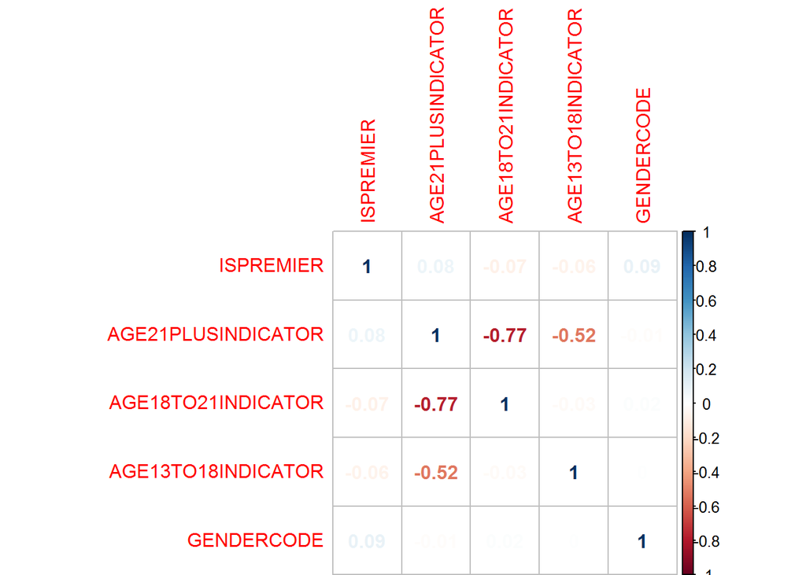

```r
library(corrplot)
 corrplot(cor(amcdata[,c(1:5)][which(amcdata$GENDERCODE!=3),]), method="number")
```

Obviously, “IsPremier” is not strongly related to any of biographic variables in this study.

### Notification variables

The notification variables include: * AMCSTUBSLOYALTYEMAILOFFEROPTININDICATOR - 0 is false; 1 is true * Opted in to receive AMC Loyalty program email offers. * AMCSTUBSREWARDSEMAILOPTININDICATOR - 0 is false; 1 is true * Opted in to receive AMC Stubs emails. * AMCSTUBSREWARDSMOBILEOPTININDICATOR - 0 is false; 1 is true * Opted in to receive AMC Stubs mobile notifications. * AMCSTUBSREWARDSSMSOPTININDICATOR - 0 is false; 1 is true * Opted in to receive AM Stubs SMS messages. * AMCSTUBSTHEATREMOBILEOFFEROPTININDICATOR - 0 is false; 1 is true * Opted in to receive AMC Stubs mobile theatre-level mobile offers. * AMCSTUBSTHEATRESMSOFFEROPTININDICATOR - 0 is false; 1 is true * Opted in to receive AMC Stubs theatre-level SMS offers.

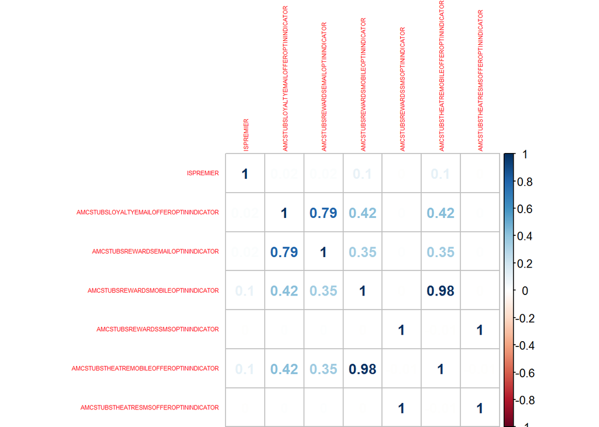

```r
library(corrplot)
 corrplot(cor(amcdata[,c(1,7,8,9,10,11,12)]), method="number",tl.cex = 0.4 )
```

Apparently, “IsPremier” is not strongly related to any notification variables.

### AMC stubs Member Financial Activities:

- LIFETIMEAMCSTUBSAWARDSEARNEDAMOUNT
- Amount of rewards in dollars that an AMC Stubs member has earned.
- LIFETIMEAMCSTUBSSPENDAMOUNT
- Amount of total spend by an AMC Stubs member.
- ONLINEFEESWAIVEDAMOUNT
- Amount of dollars in online ticketing fees waived as an AMC Stubs member.

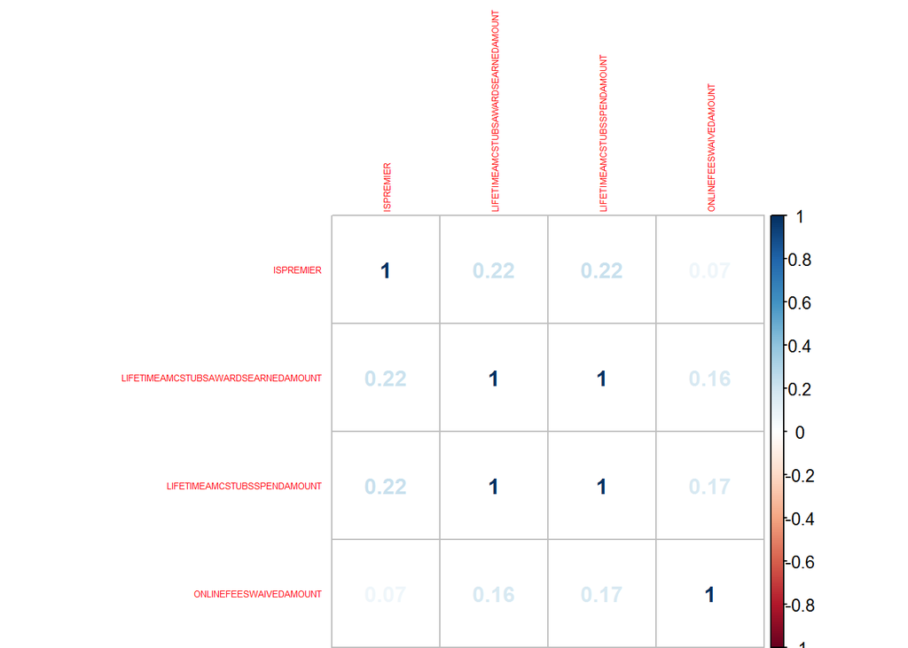

```r
library(corrplot)
 corrplot(cor(amcdata[,c(1,13,14,15)]), method="number",tl.cex = 0.4 )
```

If we consider the variables with correlation value about .2, then the “LIFETIMEAMCSTUBSAWARDSEARNEDAMOUNT” and “LIFETIMEAMCSTUBSSPENDAMOUNT” might be considered into modeling process.

### Financial Status and other AMC activities

- ESTIMATEDINCOMERANGE
- Axciom estimate of estimated income range for AMC Stubs member.
- ESTIMATEDHOMEMARKETVALUERANGE
- Axcion estimated home market value range for AMC Stubs member.
- CHILDRENPRESENCE - 0 is false; 1 is true
- Has children present in household.
- HASFREQUENTVISITTHEATRENUMBER - 0 is false; 1 is true
- Has a most frequently visited theatre selected through the site or by another means.
- TICKETQTYSUM
- Number of tickets sold to this AMC Stubs member.
- TICKETBALANCEDUESUM
- Total US dollar value of tickets sold to this AMC Stubs member.
- CONCQTYSUM
- Total number of concession items purchased by this AMC Stubs member.
- CONCLOYDISCOUNTAMTSUM
- Total amount of loyalty discount received by this AMC Stubs member (value in USD).
- CONCBALANCEDUESUM
- Total US dollar value of concessions sold to this AMC Stubs member.

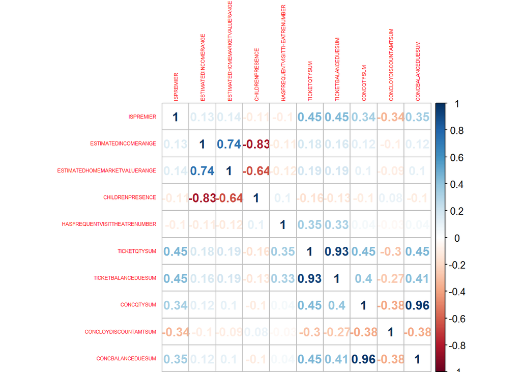

```r
library(corrplot)
 corrplot(cor(amcdata[,c(1,16,17,18,19,20,21,22,23,24)]), method="number",tl.cex = 0.4 )
```

From this result, we can see that “Is Premier” is strongly related (0.2 above) to “TICKETQTYSUM”, “TICKETBALANCEDUESUM”, “CONCQTYSUM”, “CONCLOYDISCOUNTAMTSUM” and “CONCBALANCEDUESUM”.

### Correlation test for “Is Premier” with strong variables

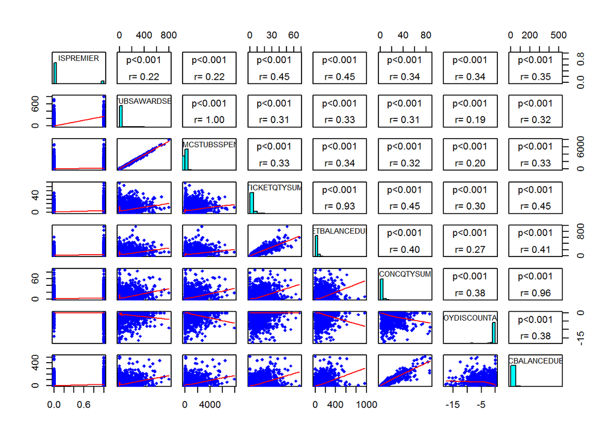

```r
panel.cor <- function(x, y, digits=2, cex.cor)
{
  usr <- par("usr"); on.exit(par(usr))
  par(usr = c(0, 1, 0, 1))
  r <- abs(cor(x, y))
  txt <- format(c(r, 0.123456789), digits=digits)[1]
  test <- cor.test(x,y)
  Signif <- ifelse(round(test$p.value,3)<0.001,"p<0.001",paste("p=",round(test$p.value,3)))
  text(0.5, 0.25, paste("r=",txt))
  text(.5, .75, Signif)
}

panel.smooth<-function (x, y, col = "blue", bg = NA, pch = 18,
                        cex = 0.8, col.smooth = "red", span = 2/3, iter = 3, ...)
{
  points(x, y, pch = pch, col = col, bg = bg, cex = cex)
  ok <- is.finite(x) & is.finite(y)
  if (any(ok))
    lines(stats::lowess(x[ok], y[ok], f = span, iter = iter),
          col = col.smooth, ...)
}

panel.hist <- function(x, ...)
{
  usr <- par("usr"); on.exit(par(usr))
  par(usr = c(usr[1:2], 0, 1.5) )
  h <- hist(x, plot = FALSE)
  breaks <- h$breaks; nB <- length(breaks)
  y <- h$counts; y <- y/max(y)
  rect(breaks[-nB], 0, breaks[-1], y, col="cyan", ...)
}

pairs(amcdata[,c(1,13,14,20,21,22,23,24)],
      lower.panel=panel.smooth, upper.panel=panel.cor,diag.panel=panel.hist)
```

From the p-value of this graph, we can see that “Is Premier” is significantly correlated with “LIFETIMEAMCSTUBSAWARDSEARNEDAMOUNT”, “LIFETIMEAMCSTUBSSPENDAMOUNT”, “TICKETQTYSUM”, “TICKETBALANCEDUESUM”, “CONCQTYSUM”, “CONCLOYDISCOUNTAMTSUM” and “CONCBALANCEDUESUM”. I will use these seven variables to predict the “Is Premier”.